# Cleaning and exploration of Lao PDR NFI cycle 4 data

ຂໍ້ມູນການສຳຫລວດປ່າໄມ້ແຫ່ງຊາດຄັ້ງທີ່ 4 ທີ່ຈັດລຽງແລ້ວ

Published

September 3, 2026

# 1 Objective

The objective of this document is to prepare calculations of biomass for the entity ‘tree’.

## 1.1 List of calculations:

- Aboveground biomass
- Tree DBH class

Before working with the tree data we will check if the data is clean.

## 1.2 Step by Step instructions

1. Setup
   1. Define user inputs
   2. Prepare environment
2. Explore data
   1. Basic information
   2. Error check
   3. Join treeplot information with tree
3. Add AGB and DBH class to each tree

# 2 Setup

Setup has 2 parts: (1) define the user inputs to specify what data to use and (2) prepare the working environment with packages, functions and data.

## 2.1 User inputs

We need to define user inputs for the scripts:

```r
usr <- list()
usr$get_new      <- TRUE
usr$get_auto     <- FALSE
usr$get_filename <- "4th_NFI_up to2025_02_24_withpath.csv"
usr$clean_all    <- FALSE
usr$time_zone    <- "Asia/Vientiane"
```

## 2.2 Environment preparation

List of actions:

1. Load packages and functions
2. Set paths to data and results
3. Get sampling design variables
4. Load ancillary data
5. Get harmonized data

In this project, each of these steps is handled by a different script stored in “*R/setup*”.

These scripts have `if (condition) { action } else { action }` statements to adapt to the source of data. There are **three sources of data** considered:

1. **master CSV from ONA** (automatic download),
2. **master CSV from a local file** or
3. **ZIP folder from a local file**.

More details on how the data are prepared can be found in “*R/setup/get-data.R*”

At this stage, the R environment contains:

- a list of user inputs.
- a list of paths to read data and write results in the correct sub-folders.
- a list of sampling design information.
- a list of data frame with the harmonized data, meaning they are structured by entity and column names are made more explicit (ex. `tree_data_basic_nest2__t_az_nest2` is renamed to `tree_azimuth`.

# 3 Data exploration

Goals:

- Get some information on the data:
- Check if errors in the data
- Join land cover type and class, and canopy height from treeplot to tree

Note: the harmonized data are stored in a list of entities

```r
exists("tree")
```

```
[1] FALSE
```

```r
exists("data_harmo")
```

```
[1] TRUE
```

```r
class(data_harmo)
```

```
[1] "list"
```

```r
names(data_harmo)
```

```
[1] "tree"     "stump"    "dw"       "treeplot" "plot"     "ntfp"
```

```r
class(data_harmo$tree)
```

```
[1] "tbl_df"     "tbl"        "data.frame"
```

```r
class(data_harmo$stump)
```

```
[1] "tbl_df"     "tbl"        "data.frame"
```

## 3.1 Basic information on data

### 3.1.1 Tree data

tree = ຕົ້ນໄມ້

data_harmo: harmonized data = ສັງລວມຂໍ້ມູນໃຫ້ເປັນ ລະບົບ ແລະ ໄຈແຍກປະເພດຂໍ້ມູນເຊັນວ່າ: ໄມ້ເປັນ, ໄມ້ຕາຍຢືນ, ໄມ້ນອນຂອນຕາຍ ແລະ ອື່ນໆ

Number of trees in the data / **ຈຳນວນຕົ້ນໄມ້ທັງຫມົດໃນຖານຂໍ້ມູນ**

```r
nrow(data_harmo$tree)
```

```
[1] 9833
```

Number of treeplots / ຈຳນວນດອນຍ່ອຍທັງຫມົດໃນຖານຂໍ້ມູນ

```r
nrow(data_harmo$treeplot)
```

```
[1] 1276
```

Number of treeplots with trees / ຈຳນວນດອນຍ່ອຍທີ່ມີຕົ້ນໄມ້ນອນຢູ່ໃນດອນຕົວຢ່າງ

```r
names(data_harmo$tree)
```

```
 [1] "ONA_parent_index"      "ONA_index"             "ONA_no"
 [4] "tree_harmo_src"        "tree_no"               "tree_stem_go"
 [7] "tree_stem_no"          "tree_distance"         "tree_azimuth"
[10] "tree_species_code"     "tree_species_newlocal" "tree_dbh"
[13] "tree_pom"              "tree_dbh100_url"
```

```r
length(unique(data_harmo$tree$ONA_parent_index))
```

```
[1] 1044
```

There are 1276 treeplots in the data but only 1044 treeplots with trees.

Manual numbers:

Automatic numbers:

ຈຳນວນດອນຍ່ອນທັງຫມົດແມ່ນ 1276 ດອນຢູ່ຖານຂໍ້ມູນ, ແຕ່ມີພຽງດອນຍ່ອຍຈຳນວນ 1044 ດອນເທົ່ານັ້ນທີມີຕົ້ນໄມ້ຢູ່ໃນດອນ.

Tree DBH distribution:

```r
summary(data_harmo$tree$tree_dbh)
```

```
   Min. 1st Qu.  Median    Mean 3rd Qu.    Max.
   10.0    13.4    20.0    25.9    34.5   139.4
```

Main species:

Requires several steps:

- group_by tree species and summarise to get the count. HINT: in `summarise()` use `n()` to count the number of elements
- arrange the data in decreasing order and keep only the first 20 rows

```r
main_species <- data_harmo$tree |>
  group_by(tree_species_code) |>
  summarise(count = n()) |>
  filter(tree_species_code != "0", tree_species_code != "9999") |>
  slice_max(n = 20, order_by = count)

print(main_species)
```

```
# A tibble: 20 × 2
   tree_species_code count
   <chr>             <int>
 1 LT0181              737
 2 LT0183              321
 3 LT0334              146
 4 LT0492              120
 5 LT0076               90
 6 LT0723               78
 7 LT0343               76
 8 LT0260               69
 9 LT0464               68
10 LT0080               59
11 LT0739               59
12 LT0184               55
13 LT0104               53
14 LT0369               51
15 LT0117               49
16 LT0188               47
17 LT0628               46
18 LT0140               45
19 LT0475               44
20 LT0725               43
```

We have species codes, let’s get the species names.

```r
main_species1 <- main_species |>
  left_join(anci$species_list, by = "tree_species_code")

print(main_species1)
```

```
# A tibble: 20 × 4
   tree_species_code count tree_species_scientific_name   tree_species_local_n…¹
   <chr>             <int> <chr>                          <chr>
 1 LT0181              737 Castanea henryi (Skan) Rehder… ກໍ່ແດງ
 2 LT0183              321 Castanopsis acuminatissima (B… ກໍ່ເດືອຍ
 3 LT0334              146 Diospyros sylvatica Roxb.      ໜັງດຳ
 4 LT0492              120 Lagerstroemia paniculata S.Vi… ເປືອຍ
 5 LT0076               90 Aporosa cardiosperma (Gaertn.… ເໝືອດແອະ
 6 LT0723               78 Schima khasiana Dyer           ຄາຍໂຊ້
 7 LT0343               76 Dipterocarpus tuberculatus Ro… ກຸງ
 8 LT0260               69 Cratoxylum maingayi Dyer       ຕີ້ວໜາມ
 9 LT0464               68 Hopea ferrea Laness.           ແຄນຫີນ
10 LT0080               59 Aporosa villosa (Lindl.) Bail… ເໝືອດຂົນ
11 LT0739               59 Shorea obtusa Wall. ex Blume   ຈິກໂຄກ
12 LT0184               55 Castanopsis argentea (Blume) … ກໍ່ຂ້າວ
13 LT0104               53 Arytera litoralis Blume        ກະດູກ
14 LT0369               51 Engelhardtia serrata Blume     ພ່າວຂຽວ
15 LT0117               49 Bauhinia variegata L.          ບານ
16 LT0188               47 Castanopsis calathiformis (Sk… ກໍ່ໜາມ
17 LT0628               46 Parashorea dussaudii Tardieu   ຊີ
18 LT0140               45 Callerya atropurpurea (Wall.)… ຂີ້ໝູປ່າ
19 LT0475               44 Irvingia malayana Oliv.ex Ben… ກະບົກ
20 LT0725               43 Schima wallichii (DC.) Korth.  ໝີ່ຄາຍ
# ℹ abbreviated name: ¹tree_species_local_name
```

```r
write_csv(main_species1, here(file.path(path$res$tab, "tree-calc-main-species.csv")))
```

We can correct the table of main species by adding the weight of the trees due to sampling design (scale factor). The scale factor is the weight of each tree if they were measured in a 1 ha plot:

$$scale\_factor = \frac{10000}{\pi \times {r}^{2}}$$

with $r$ the plot radius in meters.

R chunk description:

1. Add new columns with scale factor and tree count (1) with `mutate().`
2. Group the data by species code.
3. Calculate the sum of tree count and the sum of scale factors to get the initial number of trees per species `count` and the corrected number of trees per species if all trees were measured in 1 ha plots `count_sf`.
4. Filter out the missing species codes.
5. Keep the 20 most represented species (order_by can be switched between `count` and `count_sf` but only `count_sf` is the correct dimension).
6. Add the species names from the ancillary table in `anci$species_list`.

```r
main_species_corr <- data_harmo$tree |>
  mutate(
    tree_plot_radius = if_else(tree_dbh < 30, 8, 16),
    tree_scale_factor = 10000 / (pi * tree_plot_radius^2),
    tree_count = 1
  ) |>
  group_by(tree_species_code) |>
  summarise(
    count = sum(tree_count),
    count_sf = sum(tree_scale_factor)
  ) |>
  filter(tree_species_code != "0", tree_species_code != "9999") |>
  slice_max(n = 20, order_by = count_sf) |>
  left_join(anci$species_list, by = "tree_species_code")

## Check
# table(main_species_corr$tree_plot_radius, main_species_corr$tree_scale_factor, useNA = "ifany")
```

### 3.1.2 Treeplot data

How many treeplots:

```r
nrow(data_harmo$treeplot)
```

```
[1] 1276
```

How many land covers:

Initial result can be wrong if there are missing land covers. Need to filter out the NAs first.

```r
length(unique(data_harmo$treeplot$treeplot_lc_class))
```

```
[1] 22
```

```r
tt <- data_harmo$treeplot |> filter(!is.na(treeplot_lc_class))
length(unique(tt$treeplot_lc_class))
```

```
[1] 21
```

How many treeplot per land cover (HINT: use `table()` or `group_by()` and `summarise()`):

```r
table(data_harmo$treeplot$treeplot_lc_class, useNA = "ifany")
```

```
   11    12    13    15  16AC  16EC 16OTH  16RB  16TK    21    22    31    32
   22   610    43    14     1    12     5    31     3   133   264     1     1
   42    51    61    62    63    71    80    81  <NA>
    1    52     4     3     5     2     9     4    56
```

```r
sort(table(data_harmo$treeplot$treeplot_lc_class, useNA = "ifany"), decreasing = T)
```

```
   12    22    21  <NA>    51    13  16RB    11    15  16EC    80 16OTH    63
  610   264   133    56    52    43    31    22    14    12     9     5     5
   61    81  16TK    62    71  16AC    31    32    42
    4     4     3     3     2     1     1     1     1
```

```r
data_harmo$treeplot |>
  filter(!is.na(treeplot_lc_class)) |>
  group_by(treeplot_lc_class) |>
  summarise(count = n()) |>
  arrange(desc(count))
```

```
# A tibble: 21 × 2
   treeplot_lc_class count
   <chr>             <int>
 1 12                  610
 2 22                  264
 3 21                  133
 4 51                   52
 5 13                   43
 6 16RB                 31
 7 11                   22
 8 15                   14
 9 16EC                 12
10 80                    9
# ℹ 11 more rows
```

## 3.2 Error Check

### 3.2.1 Unrealistic DBH

We can check that there is no outlier (very small or very big tree) and that the DBH distribution per quartile is realistic with `summary()`.

```r
summary(data_harmo$tree$tree_dbh)
```

```
   Min. 1st Qu.  Median    Mean 3rd Qu.    Max.
   10.0    13.4    20.0    25.9    34.5   139.4
```

Checklist:

- No NA: **OK**
- No trees with DBH < 10: **OK**
- No trees with unrealistic DBH (400+, they exist but are very rare): **OK**
- Median and quartiles are towards the small trees: **OK**

We can also make a histogram to see the distribution per diameter class

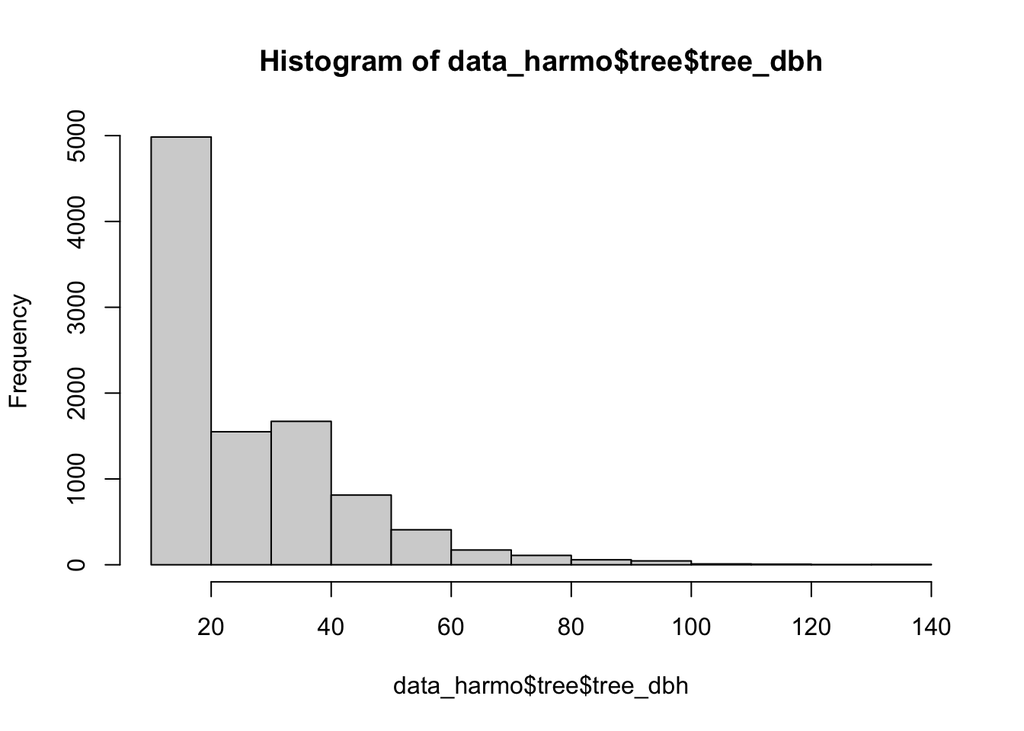

```r
hist(data_harmo$tree$tree_dbh)
```

WARNING: in this histogram there are more trees in 30-40 cm DBH than 20-30 cm. This is irregular for large inventory, but in this case it comes from the different scale factors not being considered.

Let’s make a proper DBH distribution histogram. The steps are:

1. add scale factors to trees
2. add the DBH class
3. group by dbh class and get the sum of scale factors
4. make a ggplot

For steps 1 and 2:

```r
gg_dbh <- data_harmo$tree |>
  mutate(
    tree_treeplot_radius = if_else(tree_dbh < 30, 8, 16),
    tree_scale_factor = 10000 / (pi * tree_treeplot_radius^2),
    tree_dbh_class = case_when(
      tree_dbh < 10 ~ "000-09",
      tree_dbh < 20 ~ "010-19",
      tree_dbh < 30 ~ "020-29",
      tree_dbh < 40 ~ "030-39",
      tree_dbh < 50 ~ "040-49",
      tree_dbh < 60 ~ "050-59",
      tree_dbh < 70 ~ "060-69",
      tree_dbh < 80 ~ "070-79",
      tree_dbh < 90 ~ "080-89",
      tree_dbh < 100 ~ "090-99",
      TRUE ~ "100+"
    ),
    tree_dbh_class2 = floor(tree_dbh / 10) * 10,
    tree_dbh_class2 = if_else(tree_dbh_class2 < 100, tree_dbh_class2, 100)
  )

table(gg_dbh$tree_dbh_class, useNA = "ifany")
```

```
010-19 020-29 030-39 040-49 050-59 060-69 070-79 080-89 090-99   100+
  4906   1553   1707    836    400    189    111     54     52     25
```

```r
table(gg_dbh$tree_dbh_class2, useNA = "ifany")
```

```
  10   20   30   40   50   60   70   80   90  100
4906 1553 1707  836  400  189  111   54   52   25
```

For steps 3 and 4:

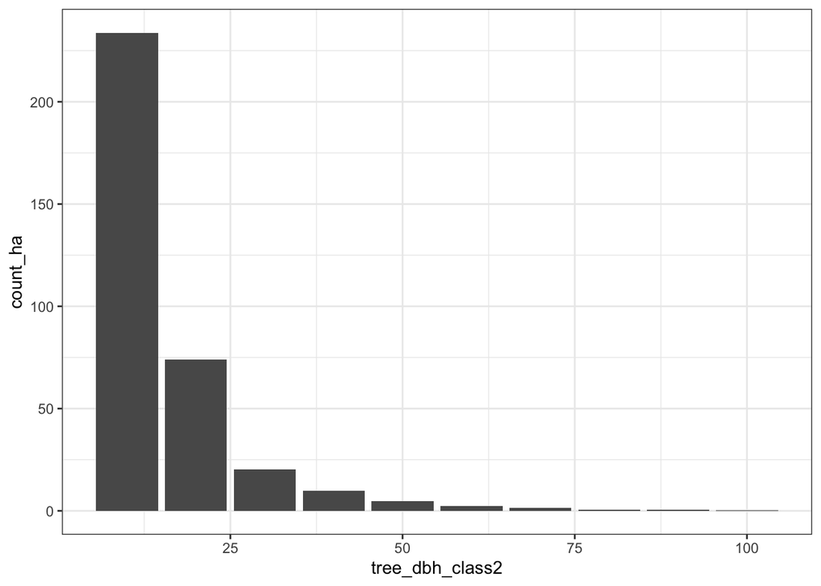

```r
n_treeplot <- length(unique(data_harmo$tree$ONA_parent_index))

gg_dbh2 <- gg_dbh |>
  group_by(tree_dbh_class2) |>
  summarise(
    count_ha = sum(tree_scale_factor) / n_treeplot,
    count = n()
  )

gg_dbh3 <- ggplot(gg_dbh2) +
  geom_col(aes(x = tree_dbh_class2, y = count_ha))

print(gg_dbh3)
```

### 3.2.2 Distance or azimuth error

We can check issues in azimuth in the `summary()`: Min and max should be 0 and 360, and as we cummulate many trees, the median and quartiles should be aligned with the cardinal points:

- 1st quartile ~ 90
- 2nd quartile ~ 180 (median)
- 3rd quartile ~ 270

```r
summary(data_harmo$tree$tree_azimuth)
```

```
   Min. 1st Qu.  Median    Mean 3rd Qu.    Max.
    0.0    89.0   178.0   178.4   267.0   360.0
```

Checklist:

- No tree less than 0 or more than 360: **OK**
- 1st quartile ~ 90: **OK**
- median ~180: **OK**
- 3rd quartile ~ 270: **OK**

### 3.2.3 Small tree measured in the large circle

We want to count how many trees have DBH < 30 but distance > 8. HINT: use `filter()` and `nrow()`.

```r
# class(data_harmo)
# class(data_harmo$tree)
# class(data_harmo$tree$tree_dbh)
# with(data_harmo$tree, tree_dbh)

check_dist <- data_harmo$tree |>
  filter(tree_dbh < 30) |>
  filter(tree_distance > 8)

nrow(check_dist)
```

```
[1] 0
```

Checklist:

- number of trees with DBH < 30 and distance > 8 = 0: **OK**

PRACTICE `filter()` and `nrow()`:

- number of trees with DBH < 10

  ```r
  dbh10 <- data_harmo$tree |>
    filter(tree_dbh < 10)

  nrow(dbh10)
  ```

  ```
  [1] 0
  ```

- number of trees with DBH class is 30-39 (tree_dbh_class2 = 30)

  ```r
  class30 <- gg_dbh |>
    filter(tree_dbh_class2 == 30)

  class30_new <- gg_dbh |>
    filter(tree_dbh_class == "030-39")

  nrow(class30)
  ```

  ```
  [1] 1707
  ```

  ```r
  nrow(class30_new)
  ```

  ```
  [1] 1707
  ```

- number of trees with stem number > 1

  ```r
  stem1 <- data_harmo$tree |>
    filter(tree_stem_no > 1)

  nrow(stem1)
  ```

  ```
  [1] 474
  ```

### 3.2.4 Errors in stem number

Tree with multiple stems count 1 for:

- *tree distribution per DBH class (to be checked)*
- importance of species,

but count separately for basal area and AGB.

To check:

1. all trees have stem number at least 1
2. all trees with stem number > 1 have a stem number 1.

EX: table with the number of trees per stem number (show the NAs). HINT: use `table()`.

```r
# class(data_harmo)
# class(data_harmo$tree)
# class(data_harmo$tree$tree_stem_no)

table(data_harmo$tree$tree_stem_no, useNA = "ifany")
```

```
   1    2    3    4    5    6    7   10 <NA>
 364  378   66   20    4    4    1    1 8995
```

```r
table(data_harmo$tree$tree_stem_go, useNA = "ifany")
```

```
multi   one  <NA>
  888  8140   805
```

checklist:

- more stem 2 than stem 1: **NOT OK**
- NAs in stem_no: **NOT OK**

We can correct when there is stem 2 but not stem 1

```r
max(data_harmo$tree$ONA_index)
```

```
[1] 8212
```

```r
summary(data_harmo$tree$ONA_index)
```

```
   Min. 1st Qu.  Median    Mean 3rd Qu.    Max.
      1    1351    2827    3435    5506    8212
```

```r
ID_stem2 <- data_harmo$tree |>
  filter(tree_stem_no == 2) |>
  select(ONA_parent_index, ONA_index, tree_stem_no) |>
  mutate(
    ONA_index_unique = ONA_parent_index * 1000 + ONA_index,
    ONA_index_unique_stem1 = ONA_index_unique - 1
    )

ID_stem12 <- data_harmo$tree |>
  mutate(ONA_index_unique = ONA_parent_index * 1000 + ONA_index) |>
  filter(ONA_index_unique %in% c(ID_stem2$ONA_index_unique, ID_stem2$ONA_index_unique_stem1))

table(ID_stem12$tree_stem_no, useNA = "ifany")
```

```
   1    2 <NA>
 332  378   38
```

ADDED OUTSIDE TRAINING

```r
tt <- data_harmo$tree
```

## 3.3 Join treeplot info

tree data doesn’t have land cover class, this information is in treeplot table. We need to get land cover class at tree level in order to apply the biomass allometric equations.

Step1: Make a treeplot table with only treeplot ID and land cover class

```r
treeplot_lc <- data_harmo$treeplot |>
  select(ONA_treeplot_id, treeplot_lc_class)
```

Step 2: Join this smaller treeplot with land cover table to the tree table

```r
tree_lc <- data_harmo$tree |>
  left_join(treeplot_lc, by = c("ONA_parent_index" = "ONA_treeplot_id"))

table(tree_lc$treeplot_lc_class, useNA = "ifany")
```

```
   11    12    13    15  16AC  16EC 16OTH  16RB  16TK    21    22    32    51
  309  6616   307   228    14    43    29   181    38   539   874    11    11
   61    80    81  <NA>
    4    18     5   606
```

Why NAs?

```r
table(data_harmo$treeplot$treeplot_lc_class, useNA = "ifany")
```

```
   11    12    13    15  16AC  16EC 16OTH  16RB  16TK    21    22    31    32
   22   610    43    14     1    12     5    31     3   133   264     1     1
   42    51    61    62    63    71    80    81  <NA>
    1    52     4     3     5     2     9     4    56
```

```r
table(data_harmo$treeplot$treeplot_access, useNA = "ifany")
```

```
accessible     danger   distance      other      slope
      1220          2          5         21         28
```

```r
access_lc <- data_harmo$treeplot |>
  filter(treeplot_access == "accessible") |>
  filter(is.na(treeplot_lc_class))

nrow(access_lc)
```

```
[1] 0
```

We have NAs in treeplot land cover but it is only in inaccessible plots. In tree table, we need to find why some treeplot are missing

```r
vec_lcna <- tree_lc |>
  filter(is.na(treeplot_lc_class)) |>
  pull(ONA_parent_index) |>
  unique() |>
  sort()

vec_lcna
```

```
 [1]  129  584  587  588  589  590  591  592  593  594  595  596  598  603  604
[16]  605  606  607  608  609  610  774  775  776  777  778  779  780  781  783
[31]  785  786  789  790  794  796 1007 1008 1009 1011 1012 1013 1014 1015 1016
[46] 1017 1018 1019 1020 1021 1022 1023 1024 1025 1026 1028 1029 1030 1031 1032
[61] 1034 1151 1152 1153 1154 1155 1156 1157 1158
```

There too many missing treeplots so that the corresponding trees have missing land cover. Potentially, we are seeing a mix of entry treeplot code error and QAQC treeplots, that the harmonization script is automatically removing.

We can come back to the initial tables to get the IDs of QAQC treeplots and remove it from `vec_lcna`.

```r
vec_qc <- data_init$treeplot_init |>
  filter(plot_info__crew_lead == "QC") |>
  pull(ONA_index) |>
  sort()
```

Now we want to remove the QAQC plots from the tree table

```r
tree_clean <- tree_lc |>
  filter(!ONA_parent_index %in% vec_qc)

vec_lcna <- tree_clean |>
  filter(is.na(treeplot_lc_class)) |>
  pull(ONA_parent_index) |>
  unique() |>
  sort()

vec_lcna
```

```
integer(0)
```

# 4 Calculations

## 4.1 Tree level calculations

Use `mutate()` and `case_when()` to assign AGB equation parameters a and b based on land cover type

# 5 Aggregation